# Sim Experiment: weekly forecast

## Intro

Experimenting with using simulation to create a week-by-week forecast, based on historical data.

### Sampling Method

Use sampling of probabilities based on historical data to create a forecast for benchmarks.

### 1. Generate some example historical data

#### basic sample data

- for each metric, get numbers for each week picked randomly from normal distribution with set mean and sd

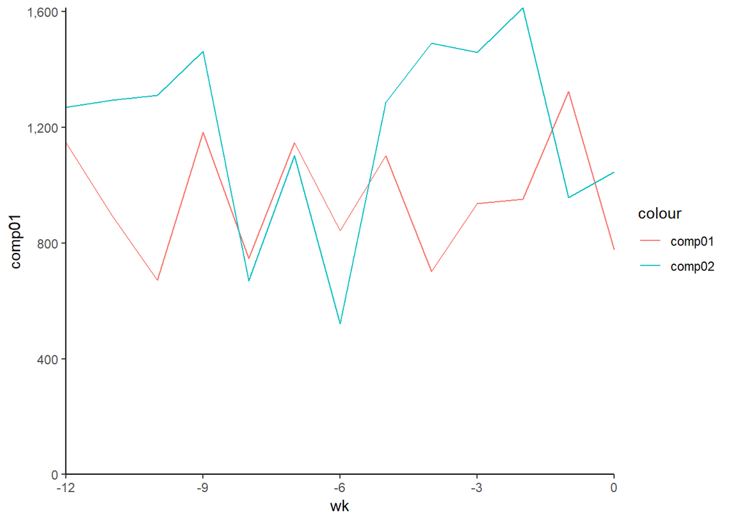

Results of data sampling for normal distribution:

- comp01: mean=1000, sd=200
- comp02: mean=1200, sd=300

#### adjust for weeks

- Activity starts slow and ramps up to week 0
- Model this by multiplying value for each week by 1/abs(w), where ‘w’ is week number (absolute value needed because weeks are negative)
- Since last week is 0, ratio calc will give infinity (Inf) so replace with 2x existing value

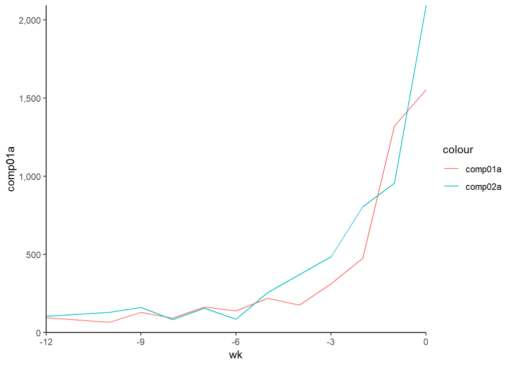

### 2. Use historical example to create new sim data

- for each week, get a randomly sampled value based on uniform dist between the existing historical values
- with some leeway allowed: 0.9 of lower value, 1.1 of upper value
- number of samples: 500

Combine sim data with original comparisons

Visualize results

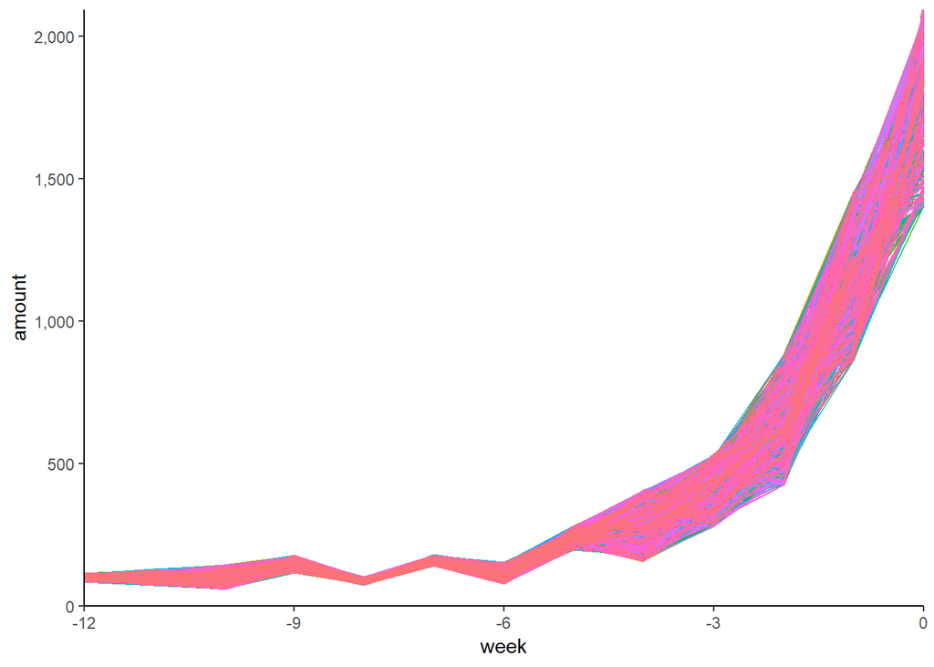

### 3. Analyze totals, means and distributions

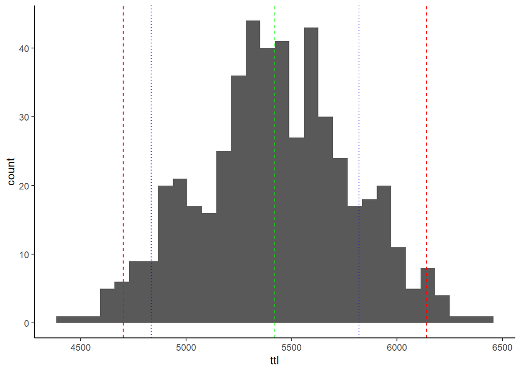

(green line is average)  
(blue lines represent totals for original comparison data sets)  
(red lines represent 2 sd above/below mean)

```
##    Min. 1st Qu.  Median    Mean 3rd Qu.    Max.
##    4452    5195    5420    5421    5661    6455
```

Based on sample distribution:

- 95% chance total will be between: 4703.0068761 and 6139.6964128

Theoretically, based on normal distribution with same mean and sd:

- 95% chance between 4717.3867073 and 6125.3165817

```r
## what amount is at pth percentile?
qnorm(p=0.5, mean=mean(comp_summary$ttl), sd=sd(comp_summary$ttl))
```

```
## [1] 5421.352
```

```r
quantile(comp_summary$ttl, 0.5)
```

```
##      50%
## 5419.908
```

```r
## probability of exactly x
dnorm(x=mean(comp_summary$ttl), mean=mean(comp_summary$ttl), sd=sd(comp_summary$ttl))
```

```
## [1] 0.001110726
```

```r
## probability of q or less
pnorm(q=mean(comp_summary$ttl), mean=mean(comp_summary$ttl), sd=sd(comp_summary$ttl))
```

```
## [1] 0.5
```

### Smoothing Method

Similar to what we are currently using: build a model based on smoothing of historical references

### 1. Apply smoothed line to chart

- need to remove the ‘color’ parameter that differentiates the two comparison sets in order to create one smooth line (otherwise, will show smooth line for each comparison set)

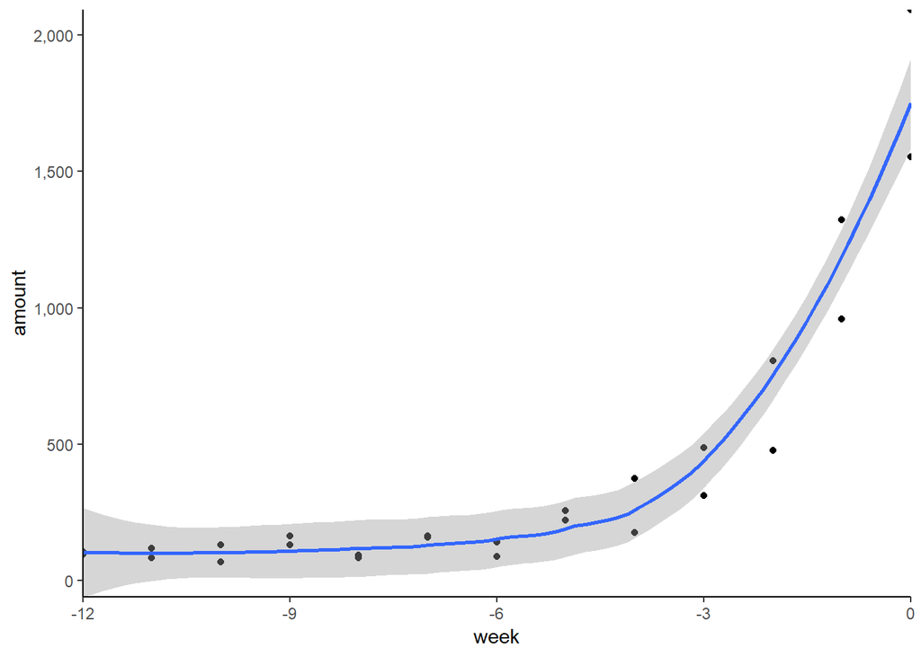

### 2. Create predictive model based on smoothing

```
## Call:
## loess(formula = amount ~ week, data = comp_orig)
##
## Number of Observations: 26
## Equivalent Number of Parameters: 4.32
## Residual Standard Error: 132.3
## Trace of smoother matrix: 4.73  (exact)
##
## Control settings:
##   span     :  0.75
##   degree   :  2
##   family   :  gaussian
##   surface  :  interpolate      cell = 0.2
##   normalize:  TRUE
##  parametric:  FALSE
## drop.square:  FALSE
```

Add model predictions to new data frame, with original historical data

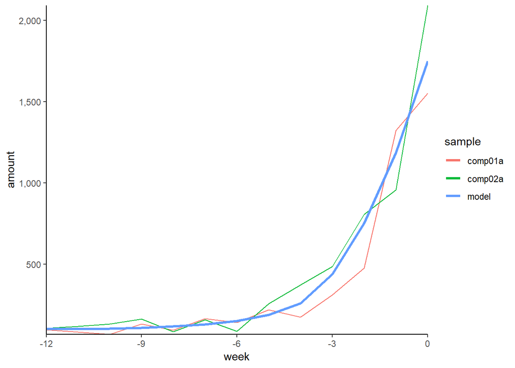

### 3. Check total amount from model

- Compare to simulation mean of 5421.3516445

```
## [1] 5393.45
```

### 4. Get confidence intervals for loess prediction

(doable but somewhat tricky…for another time)